# Exploring the effects of Receptive Fields in CNN

Optimizing CNNs through effective receptive fields

Author

Susanta Deka, Kalyani Kotti (Advisor: Dr. Cohen)

Published

Literature Review Log

Slides: slides.html

## Abstract

The receptive field of a Convolution Neural Network (CNN) is the specific region/area in input data that activates the neurons i.e. the features captured by a convolution layer. In other words, the area that a convolution layer (or filter) interacts with is the receptive field (Li, Iosifidis, and Zhang 2022). This region determines the level of feature extraction, or learning from the input which ultimately impacts the quality of the output alongside compute requirements and resource allocation. Different sizes of receptive fields may be optimal for different tasks. This also means that the effective receptive field for a given task will vary with variation in the input. For example a magnified image vs a large zoomed out scene will yield vastly different features for the same receptive field. In this study, we aim to identify the optimal sizes and combination of convolution filters for effective receptive fields as well as their compute costs. In other words, we want to experiment different configurations of convolutional filters and network architectures that affect the effective receptive field using different kernel sizes and compare the number of parameters alongside the computational cost.

## Introduction

The history of Convolution Neural Networks (CNN) is a rich one and one that spans multiple decades. CNN architecture is heavily inspired by the biology of the visual cortex, which contains arrangements of simple and complex cells that activate based on specific subregions of the visual field, known as receptive fields (Indolia et al. 2018). CNNs have made much of the buzz as well as many advancements in deep learning in recent years, particularly in the domain of computer vision and image analysis. Its application can be found in industrial settings like in fault detection, in medical imaging for disease detection through classification (Yamashita et al. 2018), or in consumer situations like face detection in digital cameras or object detection in driving systems. Moreover, researchers Gu et al. point out about the rapid growth of annotated data and the significant improvements in the processing power of graphics processor units (GPUs) which has empowered research on CNNs even further leading to many state-of-the-art models and their results on various tasks. (Gu et al. 2018)

There are numerous models and architectures of CNN. A review article by Cong and Zhou goes into details about the 6 typical architectures of CNN. A typical CNN consists of these five basic layers which are the input layer, the convolution layer, the pooling layer, the Fully Connected (FC) layer (also known as the Dense layer) and the output layer. Early advancements in CNN design are exemplified by ImageNet, more commonly known as AlexNet, which introduced the ReLu activation function instead of tanh to reduce computation complexity and resolve the vanishing gradient problem. Moreover, the use of Local Response Normalization (LRN) and pooling (down-sampling) were also helpful in improving performance as well as reducing overfitting. There’s also mention of ZfNet or DeconvNet where researchers provided visualizations to understand the internal mechanism of a CNN architecture.

The article then talks about VGG Net where researchers used smaller 3x3 CNN filters (or kernels) and deeper architectures with increased network depth. There’s also mention of GoogLeNet and its use of multiple filters of varying sizes stacked together to extract features of different sizes. The authors mention that Batch Normalization was a major contribution with the introduction of the InceptionV2 model which improved backpropagation and the gradient vanishing problem by stabilizing gradient flow, addressing issues related to internal covariate shift.

Then there’s the idea of cross-layer connection which is different from prior architectures where connections existed only between adjacent layers. Residual Networks (ResNet) implemented this cross-layer connection through shortcut connections where the input is transferred across multiple layers aenabling feature aggregation across non-adjacent layers. This is an example of widening the network which is opposite to that of deepening the network. Finally, there’s info about the DenseNet which is a CNN architecture with dense connections where each layer is connected to every other layer. A down side of this is that the model relearns the same features repeatedly and there’s increased computational overhead.

Lightweight architectures, such as MobileNetV3, are targeted towards mobile devices or embedded devices. Lightweight CNNs are smaller CNN architectures obtained after compression (reducing model size) and acceleration (increasing inference speed). MobileNetV3 is a lightweight CNN that decompose the convolution process into pointwise and depthwise convolution for decreasing model size as well as compute burden.

The fifth type of CNN architecture deals with object detection. The article introduces Regional CNN (R-CNN) which achieve object detection through three main ideas which are region proposals, feature extraction and region classification. Inspired by this and based on GoogLeNet, the YOLO model, which is You Only Look Once, segments an input image into multiple bounding boxes and classifies the regions alongside the bounding boxes to detect objects.

Finally, the sixth and the last architecture is the Transformer Encoder where the article looks into Vision Transformers (ViT). Since transformers lack spatial inductive biases which leads to poor optimization, researchers have combined CNNs and ViTs to overcome it (Cong and Zhou 2023). Collectively, these advancements underscore the dynamic interplay between architectural innovation and optimization in CNN evolution.

CNNs are inherently compute heavy because they contain a lot of parameters and structural redundancy with deeper network architectures for feature extraction. Recent advancements in lightweight deep convolutional neural networks (DCNNs) have primarily focused on optimizing network architecture to balance accuracy and computational efficiency. One of the primary strategies for achieving this balance is depthwise separable dilated convolutions, as presented in this Dual Residual and Large Receptive Field Network (DRLN) novel architecture by (Pan et al. 2024). Dilated convolutions introduce holes or spaces between kernel elements, effectively increasing the receptive field without increasing the number of parameters. ShuffleNet further enhances this approach by incorporating group convolutions and channel shuffling to improve information flow while maintaining efficiency (Zhang et al. 2017).

Other architectural innovations include EfficientNet’s compound scaling method, which uniformly scales depth, width, and resolution to optimize efficiency (Tan and Le 2020). Furthermore, NAS (Neural Architecture Search)-designed models have demonstrated promising results in automating the design of lightweight networks, with MobileNetV3 (Cong and Zhou 2023) integrating NAS techniques to improve upon its predecessors.

Another key direction in lightweight DCNNs is model compression, which reduces the memory footprint and computational burden without significantly sacrificing accuracy. Pruning techniques, such as structured and unstructured pruning, remove redundant parameters by eliminating less important weights or entire channels (Iofinova et al. 2022). Quantization, which reduces the precision of model parameters from floating-point to lower-bit representations (e.g., 8-bit integer), is another widely used technique that significantly reduces memory consumption and inference latency (Pan et al. 2024). Two widely used quantization methods are post-training quantization (PTQ) and quantization-aware-training (QAT) with PTQ being the more popular one since it can restore the performance of the model without requiring the original training pipeline (Chen et al. 2024).

Knowledge distillation has also gained traction as an effective compression method, wherein a large, well-trained teacher network transfers knowledge to a smaller student network, improving the student’s performance while keeping it computationally lightweight (Y. Wang 2022). Additionally, low-rank decomposition methods decompose weight matrices into smaller, efficient representations, further enhancing compactness.

The receptive field plays a critical role in the performance of CNNs, as it determines how much context a neuron captures. Recent studies (Luo et al. 2017) highlight that the effective receptive field (ERF) is significantly smaller than the theoretical receptive field, limiting the network’s ability to integrate global information efficiently. This phenomenon has implications for lightweight CNNs, where reducing the number of parameters can inadvertently shrink the ERF, potentially affecting recognition accuracy.

Several strategies have been proposed to mitigate this issue in lightweight networks. Dilated convolutions, for example, expand the receptive field without increasing parameter count, making them particularly useful for mobile-friendly models. Additionally, skip connections, as seen in ResNet architectures, help maintain feature propagation across layers, addressing the limitations imposed by a reduced ERF.

Benchmarking lightweight CNNs requires comprehensive evaluation across multiple datasets and hardware platforms. Common benchmark datasets such as ImageNet, CIFAR-10, and COCO are widely used to assess classification and detection performance (Pan et al. 2024),(A. N. Wang et al. 2024). However, real-world deployment also necessitates testing on edge devices to measure latency, power consumption, and memory efficiency.

Despite significant advancements, several challenges remain in designing lightweight CNNs. One area of interest is the development of hardware-aware NAS techniques that tailor models to specific device constraints. Additionally, improving the trade-off between accuracy and efficiency through novel loss functions and training paradigms remains an open research problem. Finally, better understanding and optimization of ERF in lightweight models can further enhance their effectiveness in real-world applications.

By addressing these challenges, future research can drive further improvements in lightweight CNNs, making them even more suitable for deployment in resource-constrained environments such as mobile devices, autonomous systems, and IoT applications.

## Dataset

For this project we decided to use a dataset based on the Carla (Car Learning to Act) Driving Simulator, an open-source simulator designed for autonomous driving research. Carla simulates driving scenarios that are applicable for training models for tasks like lane detection, object detection, and semantic segmentation.

- Dataset Source: [Lane Detection for Carla Driving Simulator Kaggle](https://www.kaggle.com/datasets/thomasfermi/lane-detection-for-carla-driving-simulator).
- Task: Semantic Segmentation for lane detection.
- Image Specs: The images are RGB 1024x512 pixels.
- Annotation: Each image has a corresponding label file, where lanes are marked with 1 & 2 (left & right lane pixels) and the background is marked with 0 (non-lane pixels).
- Total samples: 6408 png files = 3075 train + 3075 train_label + 129 val + 129 val_label images

#### Dataset Visualization

Example of one of the images and the corresponding label mask.

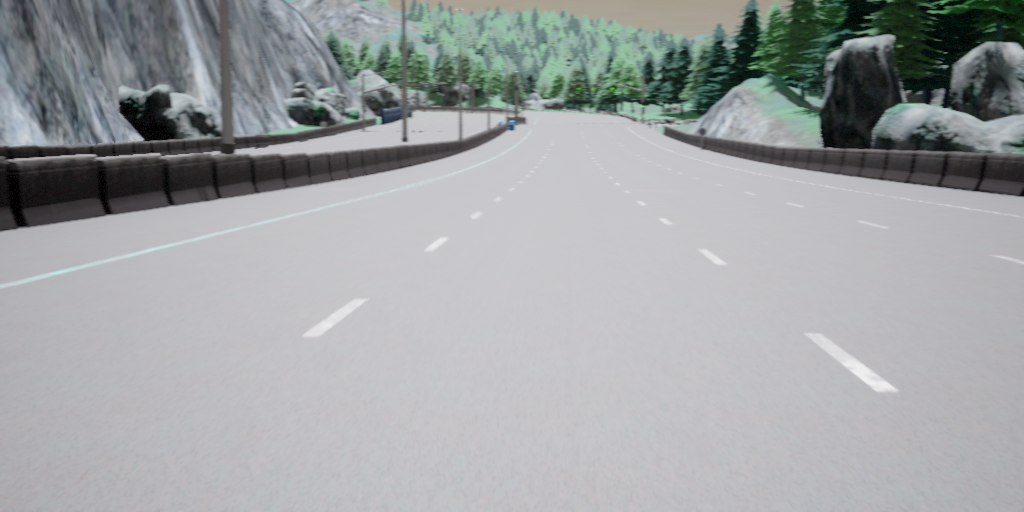

The label images are grayscale pngs with 3 pixel values, which are 0,1,2.

[figure not shown]

The following image is the label image visualized for human eyes with visually distinct color values. Here we can see the lane lines which serve as the label for training.

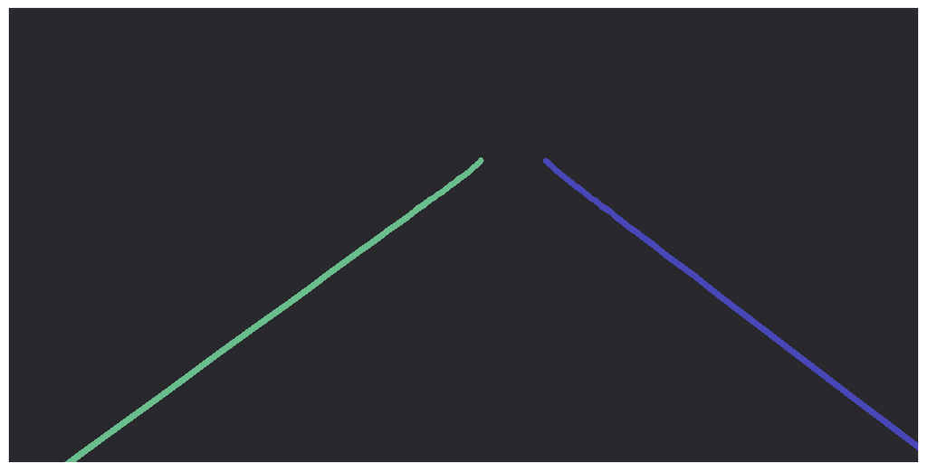

#### Exploring summary statistics of the dataset images

Since the images contain all three RGB channels, we perform some statistics to understand the distribution of each individual RGB channel as well as the RGB colors themselves.

```
RGB Means: R=158.35, G=164.14, B=163.81
RGB Medians: R=181.00, G=182.00, B=185.00
RGB Mins: R=0, G=0, B=0
RGB Maxs: R=242, G=241, B=242
RGB Standard Deviations: R=51.85, G=46.54, B=50.65
Luminosity: 162.37


Top 5 Dominant Colors (RGB, count):
     0    0    0 : 7193
   197  197  200 : 5137
   196  196  199 : 5126
   194  194  197 : 4070
   192  192  196 : 3724
```

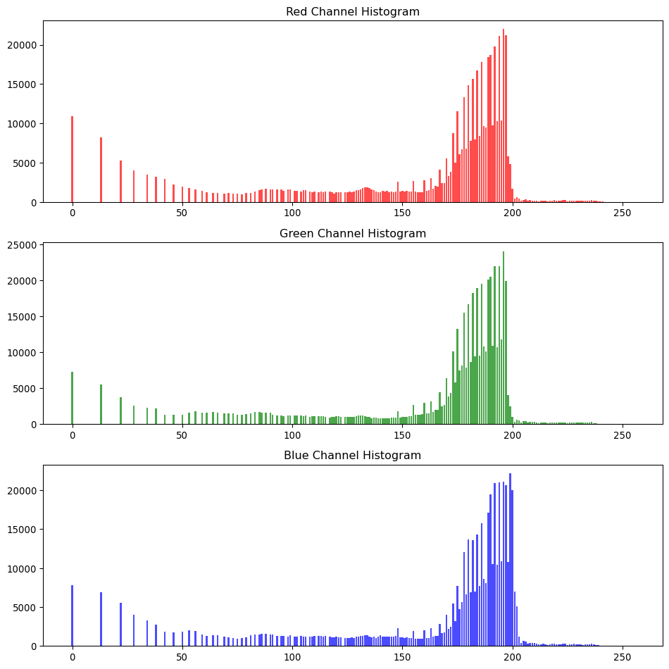

```python
import numpy as np
from PIL import Image
from skimage import color as skcolor
from collections import Counter
import matplotlib.pyplot as plt

def analyze_image(image_path):
    img = Image.open(image_path)
    img_array = np.array(img)

    rgb_means = np.mean(img_array, axis=(0, 1))
    rgb_medians = np.median(img_array, axis=(0, 1))
    rgb_mins = np.min(img_array, axis=(0, 1))
    rgb_maxs = np.max(img_array, axis=(0, 1))
    rgb_stds = np.std(img_array, axis=(0, 1))

    # Color distribution
    rgb_hist = [np.histogram(img_array[:,:,i], bins=256, range=(0,256))[0] for i in range(3)]

    # Dominant colors (top 5)
    pixels = img_array.reshape(-1, 3)
    counts = Counter(map(tuple, pixels))
    dominant_colors = counts.most_common(5)

    # Luminosity - the array of number is based on how the human eye perceives brightness in the RGB channels
    luminosity = np.dot(rgb_means, [0.299, 0.587, 0.114])

    print(f"RGB Means: R={rgb_means[0]:.2f}, G={rgb_means[1]:.2f}, B={rgb_means[2]:.2f}")
    print(f"RGB Medians: R={rgb_medians[0]:.2f}, G={rgb_medians[1]:.2f}, B={rgb_medians[2]:.2f}")
    print(f"RGB Mins: R={rgb_mins[0]}, G={rgb_mins[1]}, B={rgb_mins[2]}")
    print(f"RGB Maxs: R={rgb_maxs[0]}, G={rgb_maxs[1]}, B={rgb_maxs[2]}")
    print(f"RGB Standard Deviations: R={rgb_stds[0]:.2f}, G={rgb_stds[1]:.2f}, B={rgb_stds[2]:.2f}")
    print(f"Luminosity: {luminosity:.2f}")


    print("\n\nTop 5 Dominant Colors (RGB, count):")
    for rgb_vals, count in dominant_colors:
        print(f"  {rgb_vals[0]:4d} {rgb_vals[1]:4d} {rgb_vals[2]:4d} : {count}")

    # Plot histograms
    fig, axs = plt.subplots(3, 1, figsize=(10, 10))
    colors = ['red', 'green', 'blue']
    for i, (hist, color) in enumerate(zip(rgb_hist, colors)):
        axs[i].bar(range(256), hist, color=color, alpha=0.7)
        axs[i].set_title(f'{color.capitalize()} Channel Histogram')
    plt.tight_layout()
    plt.show()

# Usage
analyze_image("C:/Users/deka_/Desktop/Testing/Datasets/carla-lane/train/Town04_Clear_Noon_09_09_2020_14_57_22_frame_569.png")
```

Summary statistics of a sample of the training dataset. In this case we’re taking 10% of the dataset as our sample.

```python
import os

base_dir = "C:/Users/deka_/Desktop/Testing/Datasets/carla-lane/train"
all_files = os.listdir(base_dir)

all_R = np.empty((0,), dtype=np.uint8)
all_G = np.empty((0,), dtype=np.uint8)
all_B = np.empty((0,), dtype=np.uint8)
all_dominants = Counter()

sample_len = int(len(all_files) * .1)

for file in all_files[:sample_len]:
    img = Image.open(f"{base_dir}/{file}")
    img_array = np.array(img)

    pixels = img_array.reshape(-1, 3)

    all_R = np.concatenate((all_R, pixels[:,0]))
    all_G = np.concatenate((all_G, pixels[:,1]))
    all_B = np.concatenate((all_B, pixels[:,2]))

    counts = Counter(map(tuple, pixels))
    dominant_colors = counts.most_common(5)
    dominant_dict = dict(dominant_colors)
    all_dominants.update(dominant_dict)
```

> Summary statistics of the RGB channels of the sample.

```python
print(f"RGB Means:    R = {round(np.mean(all_R)):>3}, G = {round(np.mean(all_G)):>3}, B = {round(np.mean(all_B)):>3}")
print(f"RGB Medians:  R = {round(np.median(all_R)):>3}, G = {round(np.median(all_G)):>3}, B = {round(np.median(all_B)):>3}")
print(f"RGB Mins:     R = {round(np.min(all_R)):>3}, G = {round(np.min(all_G)):>3}, B = {round(np.min(all_B)):>3}")
print(f"RGB Maxs:     R = {round(np.max(all_R)):>3}, G = {round(np.max(all_G)):>3}, B = {round(np.max(all_B)):>3}")
print(f"RGB Std Devs: R = {round(np.std(all_R)):>3}, G = {round(np.std(all_G)):>3}, B = {round(np.std(all_B)):>3}")
```

```
RGB Means:    R = 159, G = 163, B = 163
RGB Medians:  R = 182, G = 183, B = 186
RGB Mins:     R =   0, G =   0, B =   0
RGB Maxs:     R = 246, G = 251, B = 252
RGB Std Devs: R =  51, G =  47, B =  51
```

> The top 5 RGB colors in the sample and their count.

```python
for rgb_vals, count in all_dominants.most_common(5):
    print(f"  {rgb_vals[0]:4d} {rgb_vals[1]:4d} {rgb_vals[2]:4d} : {count}")
```

```
   197  197  200 : 1706763
   196  196  199 : 1474997
   194  194  197 : 1313610
   199  199  202 : 825672
   199  199  203 : 657187
```

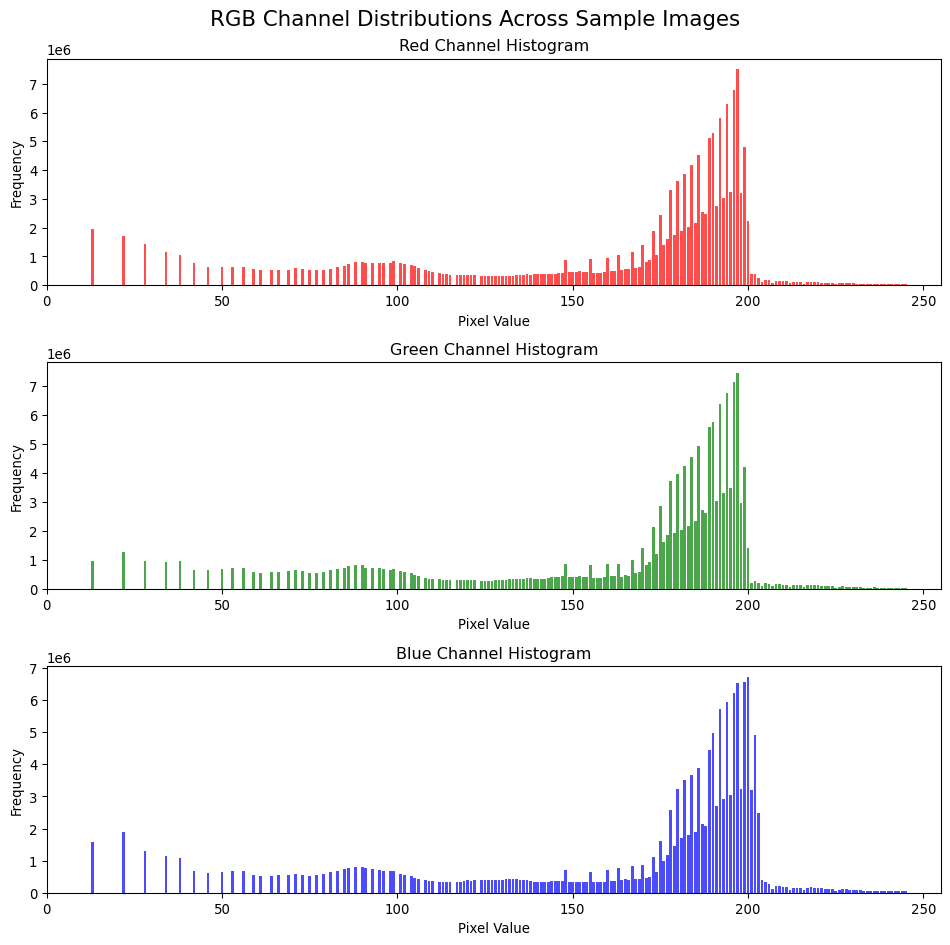

```python
rgb_hist = [
    np.histogram(all_R, bins=256, range=(0,256))[0],
    np.histogram(all_G, bins=256, range=(0,256))[0],
    np.histogram(all_B, bins=256, range=(0,256))[0]
]

fig, axs = plt.subplots(3, 1, figsize=(10, 10))
colors = ['red', 'green', 'blue']
for i, (hist, color) in enumerate(zip(rgb_hist, colors)):
    axs[i].bar(range(256), hist, color=color, alpha=0.7)
    axs[i].set_title(f'{color.capitalize()} Channel Histogram')
    axs[i].set_xlim(0, 255)  # Set consistent x-axis limits
    axs[i].set_xlabel('Pixel Value')
    axs[i].set_ylabel('Frequency')

fig.suptitle('RGB Channel Distributions Across Sample Images', fontsize=16)
plt.tight_layout()
plt.show()
```

## Methods

The main objective of this project is to compare 3×3, 5×5, and 7×7 convolution filters within two architectures: a basic CNN-based encoder-decoder and the UNet model. We aim to evaluate how filter size affects segmentation accuracy, training and evaluation time, and overall computate efficiency. The main machine learning task is semantic segmentation, specifically detecting lanes on a road. Unlike image classification where a label is assigned to an entire image, semantic segmentation goes a step further by classifying each pixel in the image to some class label.

Standard **convolution filters** with strides downsample an image to extract hierarchical features. This happens in the encoding phase. To restore spatial context in the decoding phase (or upsampling phase), **transposed convolution filters**, also known as *deconvolution* or *deconv layers*, are used to upsample feature maps for either reconstruction or decoding.

Semantic segmentation requires a model to output the final result in the same dimension as the input image. This means that the spatial information from the input needs to be carried over (or propagated) throughout the network. The final result is a label map or mask where different pixel values represent different class labels.

The following steps outline the experimental setup:

**1. Network Architecture**

> 1.a CNN Encoder-Decoder

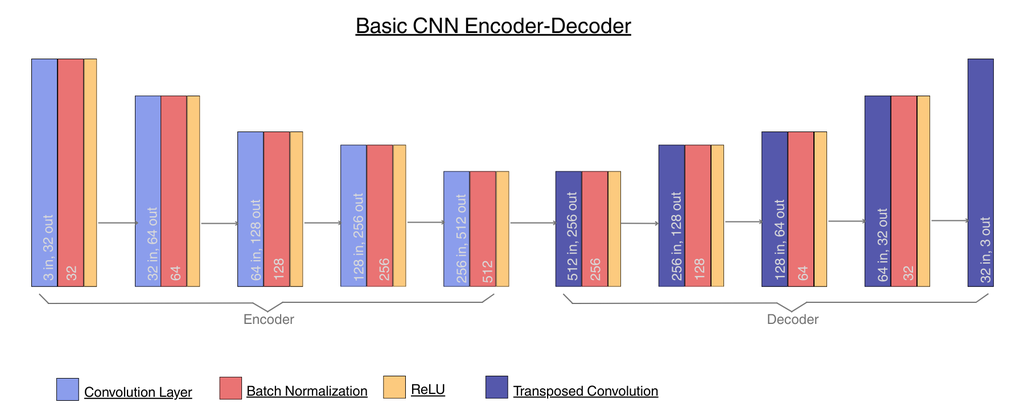

Encoder - The encoder comprises five sequential blocks, each containing:

- Strided Convolution Layers:
  - Kernel size: {3×3, 5×5, 7×7} - 3 variants of the model
  - Stride 2 with padding {1, 2, 3} for the 3 variants
  - Channel expansion: 3→32→64→128→256→512
- Feature Normalization:
  - Batch normalization (BN) layer after each convolution
- Non-linear Activation:
  - ReLU activation for feature transformation

The encoder downsamples the spatial dimensions by $2^5$ (32x downscaling).

Decoder - The decoder mirrors the encoder structure using transposed convolutions:

- Upsampling Layers:
  - Kernel-matched transposed convolutions (stride 2)
  - Output padding (1) to recover original resolution
  - Channel reduction: 512→256→128→64→32→3
- Normalization & Activation:
  - BN + ReLU combinations in all layers except final output
- Reconstruction Layer:
  - Final transposed convolution produces 3-channel output matching input dimensions

> 1.b U-Net

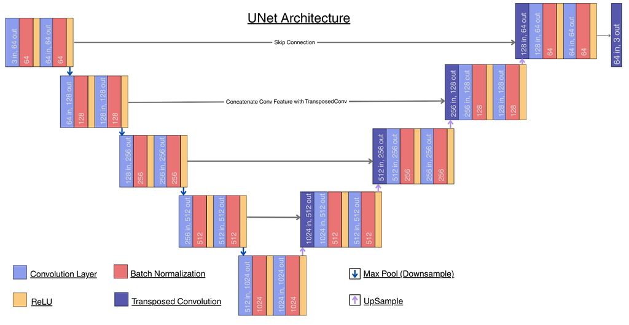

Encoder (Contracting Path) - The encoder consists of four sequential blocks, each containing:

- Double Convolutional Layers:
  - Each block applies two consecutive convolutional layers:
    - Kernel size: {3×3, 5×5, 7×7} - 3 variants of the model
    - Channel expansion: 3→64→128→256→512
    - Feature Normalization: Batch normalization (BN) after each convolution
    - Non-linear Activation: ReLU activation after each BN
  - Downsampling:
    - Max pooling (2×2, stride 2) after each block halves the spatial resolution

The encoder downsamples the spatial dimensions by a factor of $2^4$ (16× downscaling).

- Bottleneck
  - Two convolutional layers (with BN and ReLU) at the bottleneck
  - Channels: 512→1024

Decoder (Expanding Path) - The decoder mirrors the encoder structure and restores the original resolution using:

- Upsampling Layers:
  - Transposed convolutions (kernel size 2×2, stride 2) double the spatial dimensions at each step
  - Channel reduction: 1024→512→256→128→64
- Skip Connections:
  - At each upsampling stage, the upsampled feature map is concatenated with the corresponding encoder feature map (skip connection) for spatial context
  - If spatial dimensions do not match (due to rounding), the upsampled map is resized to match the encoder feature
- Double Convolutional Layers:
  - After concatenation, two convolutional layers (with BN and ReLU) refine the combined features

Output Layer

- Reconstruction Layer:
  - A final 1×1 convolution layer with 64 in channels maps the features to the desired number of output channels (3 in our case)
  - Produces an output with the same spatial dimensions as the input

**2. Training Configuration**

All three — 3×3, 5×5, and 7×7 — convolution filter variants of both the encoder-decoder and UNet models were trained for 10 epochs. We used PyTorch dataloaders to train in batches using a batch size of 25. Given that the training set contains 3,075 samples, there were 123 batches per epoch. For the loss function, we used PyTorch’s built-in cross-entropy loss, which internally applies softmax followed by negative log likelihood (NLL). This is standard for multi-class segmentation tasks and has been used in many state-of-the-art models (Yeung et al. 2022).

## Analysis and Results

Based on the model architecture, the U-Net models had significantly more parameters than the Encoder-Decoder models.

| Model | Total Params | Trainable Params | Difference with UNet |
| --- | --- | --- | --- |
| CNN 3x3 | 3,139,587 | 3,139,587 |  |
| UNet 3x3 | 31,037,763 | 31,037,763 | 27,898,176 |
| CNN 5x5 | 8,713,219 | 8,713,219 |  |
| UNet 5x5 | 81,241,411 | 81,241,411 | 72,528,192 |
| CNN 7x7 | 17,073,667 | 17,073,667 |  |
| UNet 7x7 | 156,546,883 | 156,546,883 | 139,473,216 |

> The Encoder-Decoder models are roughly 10% the size of the U-Net models.

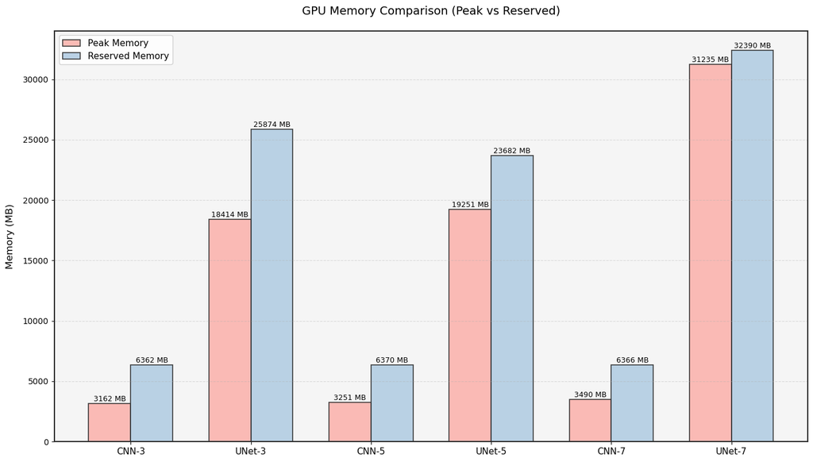

Here, peak memory represents the memory that was used for active calculation during tensor operations whereas reserved memory is the pre-allocated memory for active calculation as well as caching of repeated calculations. Since the U-Net models are big, they took higher memory and longer time to train.

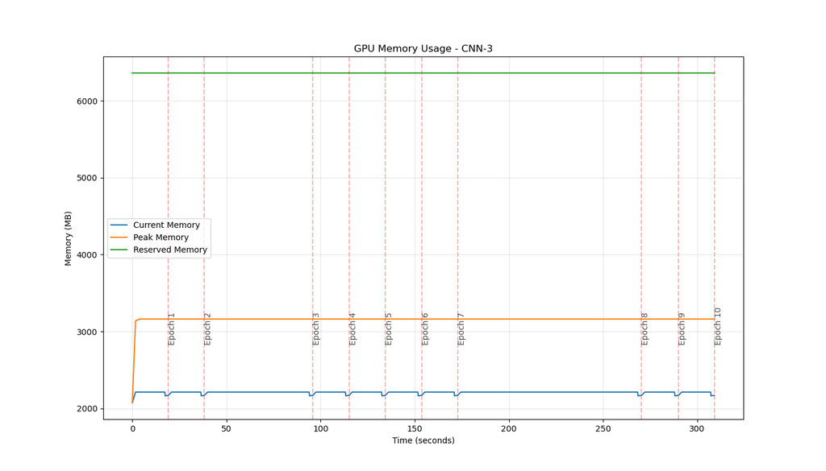

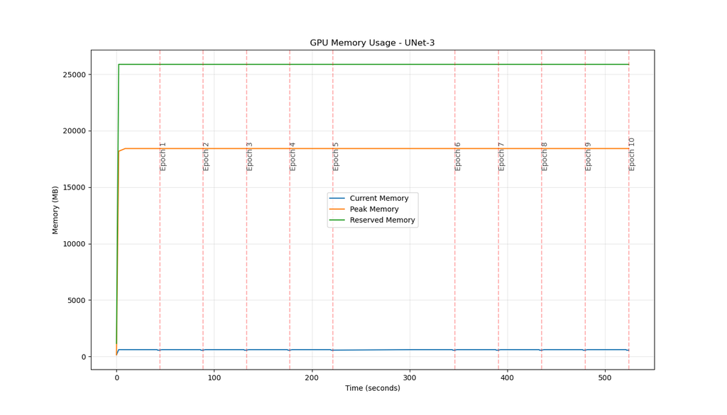

Comparing the CNN-3 vs UNet-3, it took 5 minutes to train the CNN-3 model whereas it took 8 minutes for the UNet-3 model.

## References

Chen, Fanghui, Shouliang Li, Jiale Han, Fengyuan Ren, and Zhen Yang. 2024. “Review of Lightweight Deep Convolutional Neural Networks.” *Archives of Computational Methods in Engineering* 31 (4): 1915–37. https://doi.org/10.1007/s11831-023-10032-z.

Cong, Shuang, and Yang Zhou. 2023. “A Review of Convolutional Neural Network Architectures and Their Optimizations.” *Artificial Intelligence Review* 56 (3): 1905–69. https://doi.org/10.1007/s10462-022-10213-5.

Gu, Jiuxiang, Zhenhua Wang, Jason Kuen, Lianyang Ma, Amir Shahroudy, Bing Shuai, Ting Liu, et al. 2018. “Recent Advances in Convolutional Neural Networks.” *Pattern Recognition* 77 (May): 354–77. https://doi.org/10.1016/j.patcog.2017.10.013.

Indolia, Sakshi, Anil Kumar Goswami, S. P. Mishra, and Pooja Asopa. 2018. “Conceptual Understanding of Convolutional Neural Network- A Deep Learning Approach.” *Procedia Computer Science* 132: 679–88. https://doi.org/10.1016/j.procs.2018.05.069.

Iofinova, Eugenia, Alexandra Peste, Mark Kurtz, and Dan Alistarh. 2022. “How Well Do Sparse ImageNet Models Transfer?” In *2022 IEEE/CVF Conference on Computer Vision and Pattern Recognition (CVPR)*, 12256–66. New Orleans, LA, USA: IEEE. https://doi.org/10.1109/CVPR52688.2022.01195.

Kato, Sota, and Kazuhiro Hotta. 2024. “Adaptive t-vMF Dice Loss: An Effective Expansion of Dice Loss for Medical Image Segmentation.” *Computers in Biology and Medicine* 168 (January): 107695. https://doi.org/10.1016/j.compbiomed.2023.107695.

Li, Nan, Alexandros Iosifidis, and Qi Zhang. 2022. “Collaborative Edge Computing for Distributed CNN Inference Acceleration Using Receptive Field-Based Segmentation.” *Computer Networks* 214 (September): 109150. https://doi.org/10.1016/j.comnet.2022.109150.

Luo, Wenjie, Yujia Li, Raquel Urtasun, and Richard Zemel. 2017. “Understanding the Effective Receptive Field in Deep Convolutional Neural Networks.” arXiv. https://doi.org/10.48550/arXiv.1701.04128.

Pan, Lulu, Guo Li, Ke Xu, Yanheng Lv, Wenbo Zhang, Lingxiao Li, and Le Lei. 2024. “Dual Residual and Large Receptive Field Network for Lightweight Image Super-Resolution.” *Neurocomputing* 600 (October): 128158. https://doi.org/10.1016/j.neucom.2024.128158.

Tan, Mingxing, and Quoc V. Le. 2020. “EfficientNet: Rethinking Model Scaling for Convolutional Neural Networks.” arXiv. https://doi.org/10.48550/arXiv.1905.11946.

Wang, Alex N., Christopher Hoang, Yuwen Xiong, Yann LeCun, and Mengye Ren. 2024. “PooDLe: Pooled and Dense Self-Supervised Learning from Naturalistic Videos.” arXiv. https://doi.org/10.48550/arXiv.2408.11208.

Wang, Yan. 2022. “Edge-Enhanced Feature Distillation Network for Efficient Super-Resolution.” In *2022 IEEE/CVF Conference on Computer Vision and Pattern Recognition Workshops (CVPRW)*, 776–84. New Orleans, LA, USA: IEEE. https://doi.org/10.1109/CVPRW56347.2022.00093.

Yamashita, Rikiya, Mizuho Nishio, Richard Kinh Gian Do, and Kaori Togashi. 2018. “Convolutional Neural Networks: An Overview and Application in Radiology.” *Insights into Imaging* 9 (4): 611–29. https://doi.org/10.1007/s13244-018-0639-9.

Yeung, Michael, Evis Sala, Carola-Bibiane Schönlieb, and Leonardo Rundo. 2022. “Unified Focal Loss: Generalising Dice and Cross Entropy-Based Losses to Handle Class Imbalanced Medical Image Segmentation.” *Computerized Medical Imaging and Graphics* 95 (January): 102026. https://doi.org/10.1016/j.compmedimag.2021.102026.

Zhang, Xiangyu, Xinyu Zhou, Mengxiao Lin, and Jian Sun. 2017. “ShuffleNet: An Extremely Efficient Convolutional Neural Network for Mobile Devices.” arXiv. https://doi.org/10.48550/arXiv.1707.01083.